# Customer Churn Analysis of a Telecommunications company in California from April to June 2022

#### Data and Model Problem Oversights and Future Solutions

- *Class Imbalance Problem:* Low accuracy and high misclassification for classes like Dissatisfaction, Other, and Price.

> *Future Solutions:* Use SMOTE or class weights to balance minority classes. Consider grouping low-frequency churn categories if they are semantically similar such as merge Other and Price, if justified.
- *Feature Problem:* Overlapping signals might confuse the classifier.

> *Future Solutions:* New features such as `Monthly Charge x Tenure`, `Refund Ratio`, and usage intensity. Include customer interaction history, complaint logs, or NPS scores if available.
- *Future Solutions for Model Problem:*
1. Use Tree-Based or Ensemble Models for Interpretability and Power: Try XGBoost or CatBoost for better handling of mixed feature types and imbalance.
2. Multi-Class Strategy: Evaluate other classifiers like Gradient Boosted Trees (better at handling noise) and Multinomial Logistic Regression (instead of One-vs-Rest). Also, consider hierarchical classification such as first predict churn vs. not, then predict churn reason.

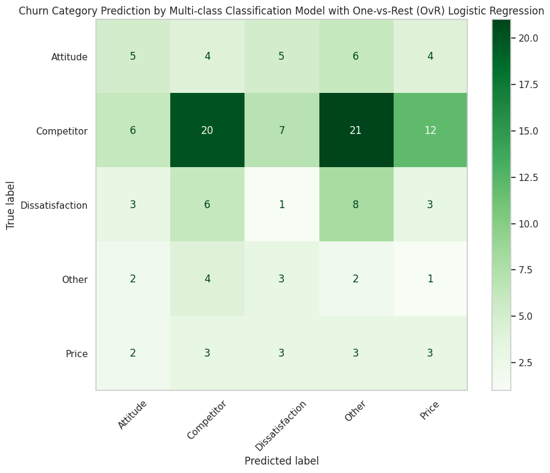

```
Accuracy Score: 22.63%
```

```python
from sklearn.linear_model import LogisticRegression
from sklearn.preprocessing import OneHotEncoder, StandardScaler
from sklearn.compose import ColumnTransformer
from sklearn.pipeline import Pipeline
from sklearn.model_selection import train_test_split
from sklearn.multiclass import OneVsRestClassifier
from sklearn.metrics import confusion_matrix, ConfusionMatrixDisplay, accuracy_score
import matplotlib.pyplot as plt
import pandas as pd

# selected features based on importance
selected_features = [
    'Contract',
    'Tenure in Months',
    'Monthly Charge',
    'Internet Type',
    'Online Security',
    'Offer',
    'Payment Method',
    'Streaming TV',
    'Streaming Movies',
    'Total Refunds',
    'Total Extra Data Charges'
]

# filter dataset to include only churned customers
churned_data = df[df['Customer Status'] == 'Churned']

X = churned_data[selected_features]
y = churned_data['Churn Category']

# define feature types
numerical = ['Tenure in Months', 'Monthly Charge', 'Total Refunds', 'Total Extra Data Charges']
categorical = list(set(selected_features) - set(numerical))

# preprocessing pipeline
preprocessor = ColumnTransformer([
    ('num', StandardScaler(), numerical),
    ('cat', OneHotEncoder(drop='first'), categorical)
])

# train/test split
X_train, X_test, y_train, y_test = train_test_split(X, y, stratify=y, test_size=0.2, random_state=42)

# pipeline with OneVsRestClassifier
model = Pipeline(steps=[
    ('preprocessor', preprocessor),
    ('classifier', OneVsRestClassifier(LogisticRegression(max_iter=1000, class_weight='balanced')))
])

# train and predict
model.fit(X_train, y_train)
y_pred = model.predict(X_test)

# confusion matrix
labels = model.named_steps['classifier'].classes_
cm = confusion_matrix(y_test, y_pred, labels=labels)

# display
fig, ax = plt.subplots(figsize=(10, 8))
disp = ConfusionMatrixDisplay(confusion_matrix=cm, display_labels=labels)
disp.plot(cmap='Greens', ax=ax, xticks_rotation=45)
ax.grid(False)

plt.title("Churn Category Prediction by Multi-class Classification Model with One-vs-Rest (OvR) Logistic Regression")
plt.tight_layout()
plt.show()

accuracy = accuracy_score(y_test, y_pred)
print(f"\nAccuracy Score: {accuracy:.2%}")
```

```
                        Feature  Importance
1                Monthly Charge    0.424992
0              Tenure in Months    0.222629
3      Total Extra Data Charges    0.052282
10   Payment Method_Credit Card    0.037085
16         Streaming Movies_Yes    0.035567
13             Streaming TV_Yes    0.035337
2                 Total Refunds    0.029555
12          Online Security_Yes    0.028108
15    Internet Type_Fiber Optic    0.024585
14            Internet Type_DSL    0.017279
11  Payment Method_Mailed Check    0.016869
8             Contract_One Year    0.016689
6                 Offer_Offer D    0.015649
5                 Offer_Offer C    0.013337
7                 Offer_Offer E    0.011715
4                 Offer_Offer B    0.011628
9             Contract_Two Year    0.006695
```

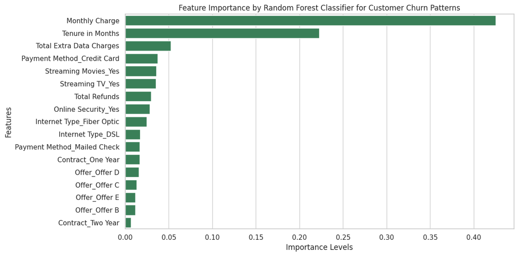

```
Accuracy Score: 22.63%
```

```python
import numpy as np
import pandas as pd
import matplotlib.pyplot as plt
import seaborn as sns
from sklearn.metrics import accuracy_score
from sklearn.ensemble import RandomForestClassifier

# define and fit a RandomForestClassifier since pipeline was not used for training
rf_classifier = RandomForestClassifier(random_state=42)
rf_classifier.fit(model.named_steps['preprocessor'].transform(X_train), y_train)

# Get feature importances
importances = rf_classifier.feature_importances_

# Get encoded feature names
ohe = model.named_steps['preprocessor'].named_transformers_['cat']
encoded_cat_cols = ohe.get_feature_names_out()

# Combine feature names
all_features = numerical + list(encoded_cat_cols)  # using numerical from previous cell

# Create importance DataFrame
importance_df = pd.DataFrame({
    'Feature': all_features,
    'Importance': importances
}).sort_values(by='Importance', ascending=False)

print(importance_df)

# Plot
plt.figure(figsize=(12, 6))
sns.barplot(x='Importance', y='Feature', data=importance_df, color='seagreen')
plt.title("Feature Importance by Random Forest Classifier for Customer Churn Patterns")
plt.xlabel("Importance Levels")
plt.ylabel("Features")
plt.tight_layout()
plt.show()

accuracy = accuracy_score(y_test, y_pred)
print(f"Accuracy Score: {accuracy:.2%}")
```

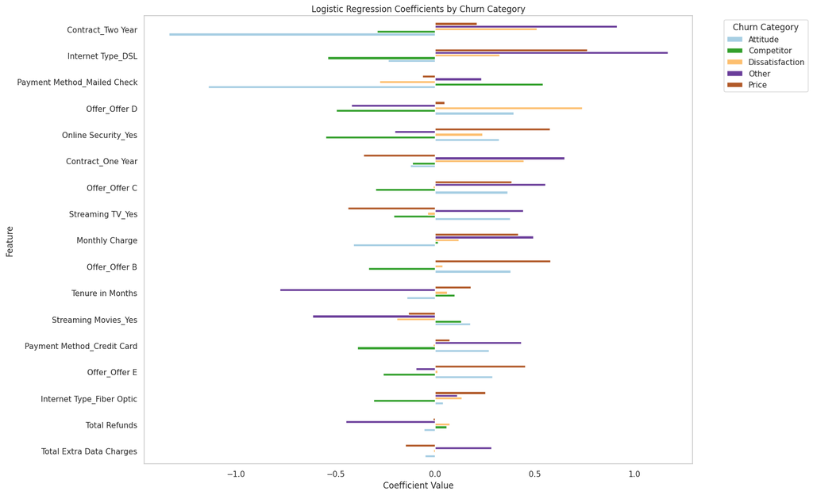

```python
import numpy as np
import pandas as pd
import matplotlib.pyplot as plt

ovr_clf = model.named_steps['classifier']
estimators = ovr_clf.estimators_

ohe = model.named_steps['preprocessor'].named_transformers_['cat']
encoded_cat_cols = ohe.get_feature_names_out()

all_features = numerical + list(encoded_cat_cols)

coef_df = pd.DataFrame(
    [est.coef_.flatten() for est in estimators],
    columns=all_features,
    index=ovr_clf.classes_
).T
coef_df['mean_abs'] = coef_df.abs().mean(axis=1)
coef_df_sorted = coef_df.sort_values(by='mean_abs', ascending=True).drop('mean_abs', axis=1)

plt.figure(figsize=(14, 10))
coef_df_sorted.plot(kind='barh', figsize=(14, 10), colormap='Paired')
plt.title("Logistic Regression Coefficients by Churn Category")
plt.xlabel("Coefficient Value")
plt.ylabel("Feature")
plt.tight_layout()
plt.legend(title="Churn Category", bbox_to_anchor=(1.05, 1), loc='upper left')
plt.grid(False)
plt.show()
```

Professional Website at [GitHub: freelancergladyslacia.github.io](https://freelancergladyslacia.github.io/)  
Contact at onbizgladyslacia@gmail.com | [linkedin.com/in/freelancergladyslacia](https://www.linkedin.com/in/freelancergladyslacia/) | facebook.com/onbizgladyslacia  
Project created in October 2024